# Data Analysis Using Statistical Packages: Basics of Inferential statistics

Sho Kuroda / 黒田翔

2024年3月 (Last update: 2024年4月)

# 1 Probability / 確率

## 1.1 Expectation and Variance of random variable

離散確率変数 $X$ の期待値と分散は確率関数 $f$ を用いて以下のように定義される．

$$\mu = E(X) = \sum_j^k x_j f(x_j)$$

$$\sigma^2 = V(X) = E[(X-E(X))^2] =
\sum_j^k (x_j - E(X))^2 f(x_j) = E(X^2) - (E(X))^2$$

連続確率変数の場合

$$\mu = E(X) = \int_{-\infty}^{\infty} x
f(x) dx$$

$$\sigma^2 = V(X) = \int_a^b (x - \mu)^2
f(x) dx$$

### 1.1.1 Example: Dice roll

例：サイコロの出目 $X$ の期待値と分散 / Example of dice roll

$$E(X) = \sum_{j=1}^6 x_j \frac{1}{6} = 1
\times \frac{1}{6} + 2 \times \frac{1}{6} + 3 \times \frac{1}{6} + 4
\times \frac{1}{6} + 5 \times \frac{1}{6} + 6 \times \frac{1}{6} =
\frac{7}{2}$$

```r
dice <- 1:6  # c(1, 2, 3, 4, 5, 6) と同じ
sum(dice * (1/6))  # definition of expectation
```

```
## [1] 3.5
```

```r
mean(dice)  # mean
```

```
## [1] 3.5
```

$$V(X) = \sum_{j=1}^6 (x_j - E(X))^2
\frac{1}{6} = \left( 1-\frac{7}{2} \right) ^2 \frac{1}{6} + \left(
2-\frac{7}{2} \right) ^2 \frac{1}{6} + \cdots + \left( 6-\frac{7}{2}
\right) ^2 \frac{1}{6} \approx 2.917$$

```r
sum((dice - mean(dice))^2 * (1/6))  # variance: sum[(x-E(X))*f(x)]
```

```
## [1] 2.916667
```

`var(dice)` は 3.5 となり，上記と一致しないが，これは `var` 関数が標本分散（不偏分散）を計算するためである．`3.5*(n-1)/n = 3.5*5/6 ≒ 2.9` である．

$V(X) = E(X^2) - (E(X))^2$ でもある．

```r
sum(dice^2 * (1/6)) - sum(dice * (1/6))^2  # variance: E(X^2)-E(X)^2
```

```
## [1] 2.916667
```

## 1.2 Z score

標準正規分布の $z = 1.96$ より左側の面積は確率 $Pr(Z \le 1.96)$ である．

`pnorm` は与えられた $z$ スコアに対応する確率を返す関数で，関数名は p (probability) + norm (normal distribution) から来ている．

```r
pnorm(q = 1.96, mean = 0, sd = 1)
```

```
## [1] 0.9750021
```

その逆に，`qnorm` は与えられた確率に対応する $z$ スコアを返す関数．

```r
qnorm(p = 0.975, mean = 0, sd = 1)
```

```
## [1] 1.959964
```

```r
qnorm(p = 0.975)  # for N(0,1), the mean and sd arguments may be omitted
```

```
## [1] 1.959964
```

確率密度． `dnorm` = d (density) + norm (normal distribution).

```r
dnorm(x = 1.96, mean = 0, sd = 1)
```

```
## [1] 0.05844094
```

標準正規分布の確率密度 $\phi$ を積分する（確率密度関数とX軸の間の面積を計算する）と，積分区間の間の値を取る確率が得られる．

$$\Pr(-1.96 \le Z \le 1.96) =
\int_{-1.96}^{1.96} \phi(z) dz \approx 0.95$$

```r
integrate(dnorm, -1.96, 1.96)  # 積分: 約 95%
```

```
## 0.9500042 with absolute error < 1e-11
```

この `dnorm` 関数は密度関数の描画にも使える．

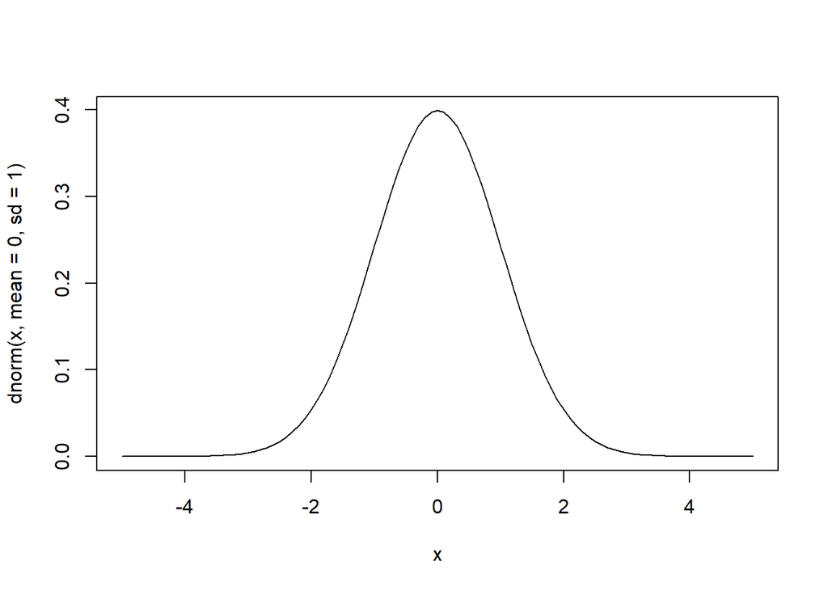

```r
curve(dnorm(x, mean = 0, sd = 1), xlim = c(-5, 5))
```

## 1.3 Generating random numbers / 乱数の生成

一様分布から乱数をドローするには，`runif`関数を使う．この関数名は r (random) + unif (uniform distribution) から来ている．

```r
runif(n = 5, min = 0, max = 1)
```

```
## [1] 0.045721862 0.913803483 0.857489535 0.006639619 0.657664942
```

```r
runif(5, 0, 1)  # 引数の順番を守れば「n=」などを省略可
```

```
## [1] 0.94807596 0.54706138 0.95187362 0.07074964 0.80055770
```

```r
runif(5, 0, 1)  # min = 0 かつ max = 1 の場合は省略可（デフォルトの設定）
```

```
## [1] 0.94054028 0.59023833 0.03907224 0.47283295 0.40004483
```

乱数をドローするたびに異なる値が出力される． 再現性のために乱数のシードを指定することができる．

```r
set.seed(0)
runif(5)
```

```
## [1] 0.8966972 0.2655087 0.3721239 0.5728534 0.9082078
```

```r
set.seed(0)
runif(5)
```

```
## [1] 0.8966972 0.2655087 0.3721239 0.5728534 0.9082078
```

正規乱数（正規分布からドローする乱数）は `rnorm` で生成できる．

```r
rnorm(n = 5, mean = 0, sd = 10)
```

```
## [1] -8.356286 15.952808  3.295078 -8.204684  4.874291
```

### 1.3.1 Expectation and variance: Random variables from the uniform distribution

一様分布 $U(a, b)$ から乱数を生成して標本平均と標本分散を計算し，それが理論値と一致するかを確認する．

$$E(X) = \int_a^b x \frac{1}{b-a} dx =
\frac{1}{b-a} \left[ \frac{x^2}{2} \right]_a^b = \frac{1}{b-a} \times
\frac{b^2 - a^2}{2} = \frac{a+b}{2}$$

$$V(X) = \int_a^b (x - \mu)^2
\frac{1}{b-a} dx = \frac{1}{b-a} \left[ \frac{ \left( x - \frac{a+b}{2}
\right)^3}{3} \right]_a^b = \frac{(b - a)^2}{12}$$

$X \sim U(-1, 1)$ とすると，母平均と母分散は次の値となる．

$$E(X) = \frac{a+b}{2} = \frac{-1+1}{2} =
0$$

$$V(X) = \frac{(b - a)^2}{12} = \frac{(1
- (-1))^2}{12} = \frac{1}{3}$$

一様分布に従う乱数は `runif(n = サンプルサイズ, min = 下限, max = 上限)` で生成できる (`runif` = random + uniform)．

```r
runif(n = 5, min = -1, max = 1)
```

```
## [1]  0.539682840 -0.004601516  0.435237017  0.983812190 -0.239929641
```

「サンプルサイズ 100 で一様乱数を生成して平均と分散を計算する」を 1,000 回繰り返す．このようなシミュレーションを「モンテカルロ・シミュレーション」と呼ぶ．

```r
runif_mean <- runif_var <- NULL
for (i in 1:1000) {
  set.seed(i)  # 再現性のため
  runif_i <- runif(n = 100, min = -1, max = 1)
  runif_mean <- c(runif_mean, mean(runif_i))
  runif_var <- c(runif_var, var(runif_i))
}
summary(runif_mean)
```

```
##       Min.    1st Qu.     Median       Mean    3rd Qu.       Max.
## -1.842e-01 -4.050e-02 -4.024e-05 -1.030e-03  3.643e-02  2.225e-01
```

```r
summary(runif_var)
```

```
##    Min. 1st Qu.  Median    Mean 3rd Qu.    Max.
##  0.2413  0.3127  0.3327  0.3333  0.3545  0.4225
```

# 2 Sampling / サンプリング

## 2.1 Central limit theorem / 中心極限定理

一様確率変数の標本平均の分布を求める．標本サイズが大きくなるほど正規分布に近づき，分布の分散が小さくなることが分かる．

### 2.1.1 $n=1$

これは乱数そのものの分布と等しい．

$$\bar{x} = x_i, \quad x_i \sim U(0, 1)$$

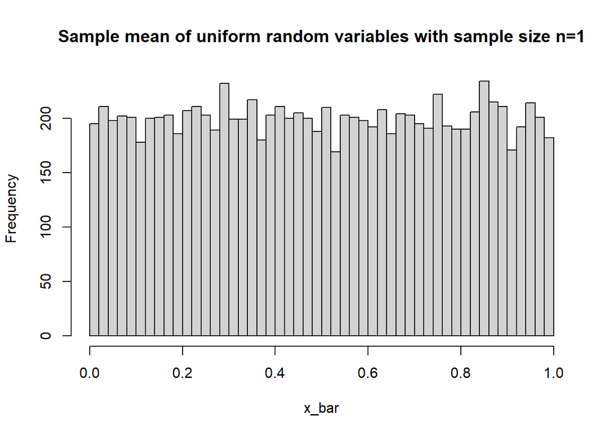

```r
x_bar <- NULL  # create empty (null) object
for (i in 1:10000) {
  x_bar_i <- mean(runif(n = 1, min = 0, max = 1))
  x_bar <- c(x_bar, x_bar_i)
}
hist(x_bar, breaks = 50, main = "Sample mean of uniform random variables with sample size n=1")
```

### 2.1.2 $n=2$

$$\bar{x} = \frac{1}{2} \sum_{i=1}^{2}
x_i, \quad x_i \sim U(0, 1)$$

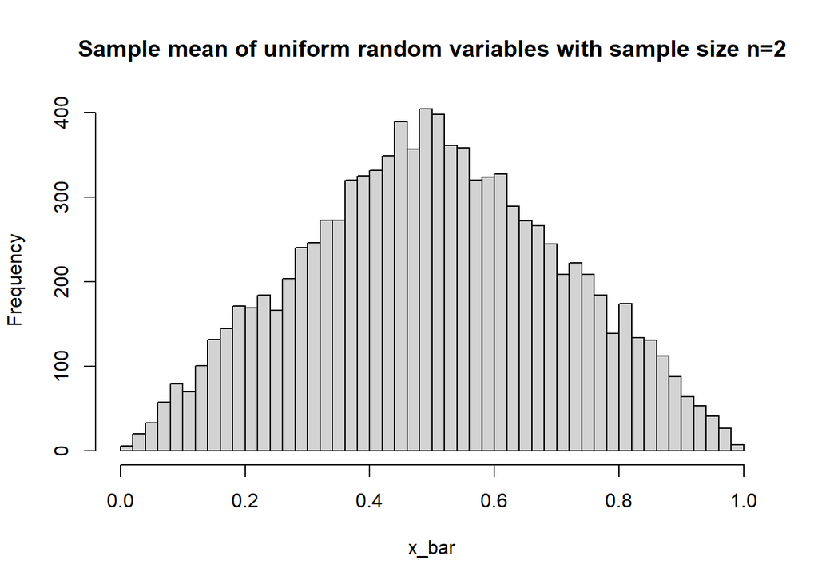

```r
x_bar <- NULL
for (i in 1:10000) {
  x_bar_i <- mean(runif(n = 2, min = 0, max = 1))
  x_bar <- c(x_bar, x_bar_i)
}
hist(x_bar, breaks = 50, main = "Sample mean of uniform random variables with sample size n=2")
```

### 2.1.3 $n=10$

$$\bar{x} = \frac{1}{10} \sum_{i=1}^{10}
x_i, \quad x_i \sim U(0, 1)$$

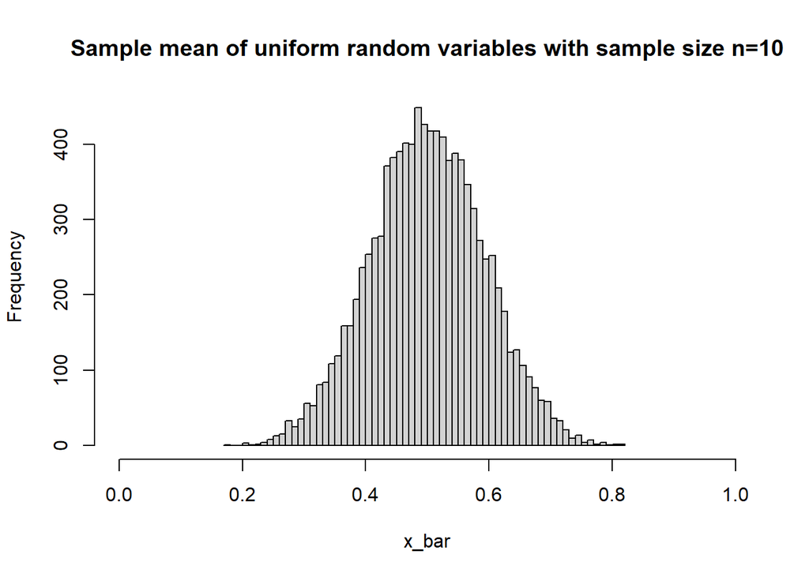

```r
x_bar <- NULL
for (i in 1:10000) {
  x_bar_i <- mean(runif(n = 10, min = 0, max = 1))
  x_bar <- c(x_bar, x_bar_i)
}
hist(x_bar, breaks = 50, main = "Sample mean of uniform random variables with sample size n=10",
     xlim = c(0, 1))
```

### 2.1.4 For advanced students / 上級者向け

実は，`for`文を使わずに`sapply`関数を使って次のように書くこともできる：

`hist(sapply(X = 1:10000, FUN = function (x) mean(runif(10)) ), breaks = 50)`

# 3 Confidence interval / 信頼区間

## 3.1 Population mean with known $\sigma$ / 標準偏差が既知の場合の母平均

標本平均が100，「母集団」の標準偏差が2，サンプルサイズが100の場合，信頼区間は次のように計算される．

$$\bar{x} \pm z \frac{\sigma}{\sqrt{n}} =
100 \pm 1.96 \frac{2}{\sqrt{100}} = 100 \pm 0.392, \quad \mbox{95% CI}:
[99.61, 100.39]$$

```r
qnorm(p = 0.025, mean = 0, sd = 1)  # P(Z<z) = 0.025
```

```
## [1] -1.959964
```

```r
qnorm(p = 0.975, mean = 0, sd = 1)  # P(Z<z) = 0.975
```

```
## [1] 1.959964
```

```r
100 + qnorm(p = 0.025) * 2 / sqrt(100)  # lower limit
```

```
## [1] 99.60801
```

```r
100 + qnorm(p = 0.975) * 2 / sqrt(100)  # upper limit
```

```
## [1] 100.392
```

## 3.2 Population mean with unknown $\sigma$ / 標準偏差が未知の場合の母平均

標本平均が100，「標本」標準偏差が2，サンプルサイズが100の場合，信頼区間は次のようになる．

$$\bar{x} \pm t \frac{s}{\sqrt{n}} = 100
\pm 1.98 \frac{2}{\sqrt{100}} = 100 \pm 0.396, \quad \mbox{95% CI}:
[99.60, 100.40]$$

```r
qt(p = 0.025, df = 100-1)  # P(T<t) = 0.025
```

```
## [1] -1.984217
```

```r
100 + qt(p = 0.025, df = 100-1) * 2 / sqrt(100)  # lower limit
```

```
## [1] 99.60316
```

```r
100 + qt(p = 0.975, df = 100-1) * 2 / sqrt(100)  # upper limit
```

```
## [1] 100.3968
```

### 3.2.1 Using `t.test` function

$t$-検定を行う`t.test`という関数は信頼区間をついでに出力してくれる．

```r
wage <- c(1000, 1200, 1300, 1200, 1150, 1000, 1450, 1500, 1150, 1350)
mean(wage)  # mean
```

```
## [1] 1230
```

```r
sd(wage)  # standard deviation
```

```
## [1] 170.2939
```

```r
length(wage)  # sample size (length of the vector)
```

```
## [1] 10
```

```r
mean(wage) + qt(p = 0.025, df = length(wage)-1) * sd(wage) / sqrt(length(wage))  # lower bound
```

```
## [1] 1108.179
```

```r
mean(wage) + qt(p = 0.975, df = length(wage)-1) * sd(wage) / sqrt(length(wage))  # upper bound
```

```
## [1] 1351.821
```

```r
t.test(wage)  # default: 95% CI
```

```
##
##  One Sample t-test
##
## data:  wage
## t = 22.841, df = 9, p-value = 2.806e-09
## alternative hypothesis: true mean is not equal to 0
## 95 percent confidence interval:
##  1108.179 1351.821
## sample estimates:
## mean of x
##      1230
```

```r
t.test(wage, conf.level = 0.99)  # 99% CI
```

```
##
##  One Sample t-test
##
## data:  wage
## t = 22.841, df = 9, p-value = 2.806e-09
## alternative hypothesis: true mean is not equal to 0
## 99 percent confidence interval:
##  1054.991 1405.009
## sample estimates:
## mean of x
##      1230
```

## 3.3 Population proportion / 母比率

$$p \pm z \sqrt{\frac{p (1-p)}{n}}$$

Example of [Banerjee, Duflo, and Glennerster (BMJ 2010)](https://www.bmj.com/content/340/bmj.c2220)

382人の子供のうち148人がワクチンの予防接種を受けた．

```r
n1 <- 148; n0 <- 382  # intervention B
p <- n1 / n0
p
```

```
## [1] 0.3874346
```

```r
p + qnorm(p = .025) * sqrt(p * (1 - p) / n0)  # lower limit of 95% CI
```

```
## [1] 0.3385815
```

```r
p + qnorm(p = .975) * sqrt(p * (1 - p) / n0)  # upper limit
```

```
## [1] 0.4362876
```

実は，この数値は論文中で報告されている数値とは異なる．地理的なブロック（村）を用いてクラスター無作為化対照試験が実行されたため，著者らはこのデータの階層性を考慮したより複雑な計算をしていると思われる．

# 4 Statistical hypothesis testing / 統計的仮説検定

## 4.1 One-sample $t$ test for population mean / 1標本の母平均の $t$ 検定

### 4.1.1 Calculation from the sample mean and sd of the data / データの標本平均・標準偏差から計算

賃金の母集団が正規分布で，$\sigma$ は未知，$\bar{x} = 1230, s=170.3, n = 10, \alpha=0.05$ とする．

$$H_0: \mu = 1100, \quad H_1: \mu \ne
1100$$

$$t = \frac{\bar{x} - \mu_0}{s/\sqrt{n}}
= \frac{1230 - 1110}{170.3 / \sqrt{10}} \approx 2.41$$
$$\Pr (T \le 2.41) = 0.98 , \quad 2 \times (1 -
\Pr (T \le 2.41)) \approx 0.039$$

```r
t_value <- (1230 - 1100) / (170.3 / sqrt(10))  # t value
t_value
```

```
## [1] 2.413952
```

```r
pt(q = t_value, df = 10 - 1)  # Pr(T <= t)
```

```
## [1] 0.9805023
```

```r
1 - pt(q = t_value, df = 10 - 1)  # one sided p value ... p = Pr(T > t)
```

```
## [1] 0.01949773
```

```r
2 * (1 - pt(q = t_value, df = 10 - 1))  # two sided p value
```

```
## [1] 0.03899546
```

よって，$H_0$ は棄却され $H_1$ が採択される．

### 4.1.2 Calculation from the data itself / データそのものから計算

```r
wage <- c(1000, 1200, 1300, 1200, 1150, 1000, 1450, 1500, 1150, 1350)
mean(wage); sd(wage)
```

```
## [1] 1230
```

```
## [1] 170.2939
```

```r
t.test(wage, mu = 1100)  # default: two sided ... H1 is [mu /= 1150]
```

```
##
##  One Sample t-test
##
## data:  wage
## t = 2.414, df = 9, p-value = 0.03899
## alternative hypothesis: true mean is not equal to 1100
## 95 percent confidence interval:
##  1108.179 1351.821
## sample estimates:
## mean of x
##      1230
```

```r
t.test(wage, mu = 1100, alternative = "greater")  # one sided ... H1 is [mu > 1150]
```

```
##
##  One Sample t-test
##
## data:  wage
## t = 2.414, df = 9, p-value = 0.01949
## alternative hypothesis: true mean is greater than 1100
## 95 percent confidence interval:
##  1131.284      Inf
## sample estimates:
## mean of x
##      1230
```

このように信頼区間も同時に計算してくれる．

## 4.2 Two-sample $t$ test for population mean / 2標本の母平均の $t$ 検定

### 4.2.1 Independent $t$ test

#### 4.2.1.1 Example of “wage” data

```r
wage_jp <- c(1000, 1200, 1300, 1200, 1150, 1000, 1450, 1500, 1150, 1350)  # Japan
wage_us <- c(900, 1300, 1200, 800, 1600, 850, 1000, 950)  # US
t.test(wage_jp, wage_us)  # default: Welch's t test (assuming unequal variance)
```

```
##
##  Welch Two Sample t-test
##
## data:  wage_jp and wage_us
## t = 1.4041, df = 11.205, p-value = 0.1874
## alternative hypothesis: true difference in means is not equal to 0
## 95 percent confidence interval:
##  -87.42307 397.42307
## sample estimates:
## mean of x mean of y
##      1230      1075
```

```r
t.test(wage_jp, wage_us, var.equal = TRUE)  # t test (assuming equal variance)
```

```
##
##  Two Sample t-test
##
## data:  wage_jp and wage_us
## t = 1.479, df = 16, p-value = 0.1586
## alternative hypothesis: true difference in means is not equal to 0
## 95 percent confidence interval:
##  -67.16377 377.16377
## sample estimates:
## mean of x mean of y
##      1230      1075
```

#### 4.2.1.2 Titanic data

データ読み込み．

```r
titanic <- read.csv("https://raw.githubusercontent.com/kurodaecon/bs/main/data/titanic3_csv.csv")
```

性別によって年齢の平均値が異なるかどうかの検定．

```r
t.test(x = titanic$age[titanic$sex == "female"], y = titanic$age[titanic$sex == "male"])
```

```
##
##  Welch Two Sample t-test
##
## data:  titanic$age[titanic$sex == "female"] and titanic$age[titanic$sex == "male"]
## t = -2.0497, df = 798.36, p-value = 0.04072
## alternative hypothesis: true difference in means is not equal to 0
## 95 percent confidence interval:
##  -3.71593356 -0.08034711
## sample estimates:
## mean of x mean of y
##  28.68709  30.58523
```

```r
t.test(age ~ sex, data = titanic)  # same as above
```

```
##
##  Welch Two Sample t-test
##
## data:  age by sex
## t = -2.0497, df = 798.36, p-value = 0.04072
## alternative hypothesis: true difference in means between group female and group male is not equal to 0
## 95 percent confidence interval:
##  -3.71593356 -0.08034711
## sample estimates:
## mean in group female   mean in group male
##             28.68709             30.58523
```

$p < 0.05$ なので，「年齢の平均値は男性と女性で等しい」という帰無仮説を有意水準5%で棄却できる． 男性の標本平均の方が高いことと合わせると，「男性の方が有意に平均年齢が高い」と言える．

サブサンプルに対して検定する場合やデータフレームを加工して作成した変数を用いて検定する場合はパイプ演算子を使うと便利（`tidyverse` が必要）．

```r
library(tidyverse)
titanic %>%
  filter(pclass == 1) %>%
  t.test(age ~ sex, data = .)
```

```
##
##  Welch Two Sample t-test
##
## data:  age by sex
## t = -2.3283, df = 278.85, p-value = 0.02061
## alternative hypothesis: true difference in means between group female and group male is not equal to 0
## 95 percent confidence interval:
##  -7.3664537 -0.6169013
## sample estimates:
## mean in group female   mean in group male
##             37.03759             41.02927
```

### 4.2.2 Paired (dependent) $t$ test

```r
wage_w <- c(1000, 1200, 1300, 1200, 1150, 1000, 1450, 1500, 1150, 1350)  # wife
wage_h <- c(900, 1300, 1200, 800, 1600, 850, 1000, 950, 1200, 1400)  # husband
# length(wage_w); length(wage_h)  # = 10
t.test(wage_w, wage_h, paired = TRUE)
```

```
##
##  Paired t-test
##
## data:  wage_w and wage_h
## t = 1.1638, df = 9, p-value = 0.2744
## alternative hypothesis: true mean difference is not equal to 0
## 95 percent confidence interval:
##  -103.8108  323.8108
## sample estimates:
## mean difference
##             110
```

```r
t.test(wage_w - wage_h)  # same as an ordinary "one-sample t test"
```

```
##
##  One Sample t-test
##
## data:  wage_w - wage_h
## t = 1.1638, df = 9, p-value = 0.2744
## alternative hypothesis: true mean is not equal to 0
## 95 percent confidence interval:
##  -103.8108  323.8108
## sample estimates:
## mean of x
##       110
```

## 4.3 Multiple testing problem: Simulation / 多重検定の問題に関するシミュレーション

「標準正規分布 $N(0, 1)$ から $n=100$ の乱数をドローして，その平均が 0 に等しいかどうかを検定する」という手続きを1,000回繰り返し，検定で計算されたp値の分布を観察する．

One-sample test for population mean: $H_0: \mu = 0$

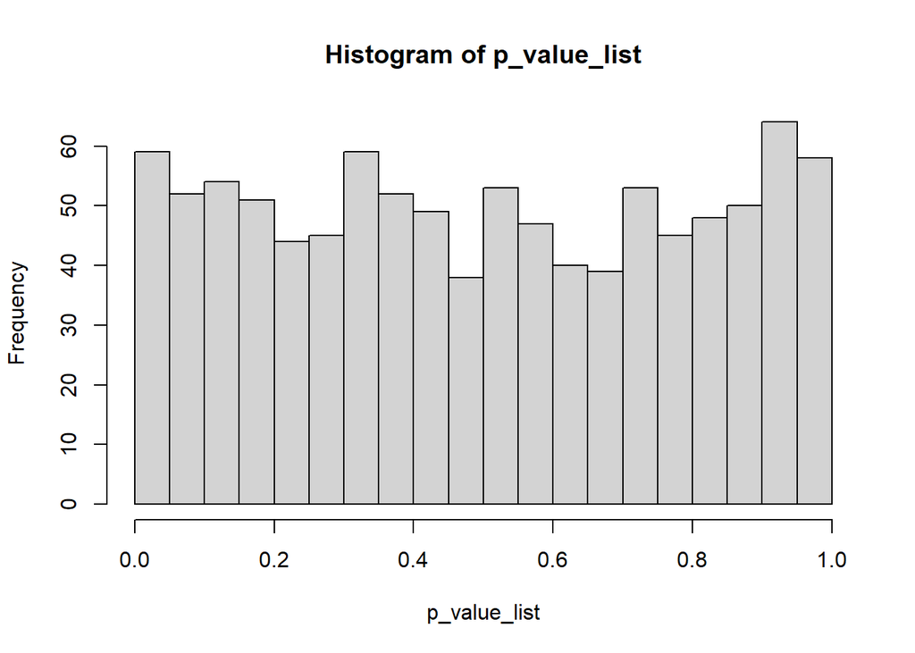

```r
p_value_list <- NULL
for (i in 1:1000) {
  p_value_list <- c(p_value_list, t.test(rnorm(100, mean = 0, sd = 1))$p.value)
}
hist(p_value_list, breaks = 20)
```

```r
table(p_value_list <= 0.05)
```

```
##
## FALSE  TRUE
##   941    59
```

母集団分布の母平均は $\mu = 0$ であるからこの帰無仮説は棄却されないことが望まれるが，上記の通り5%程度の確率で誤って棄却されてしまう（第一種の過誤）．

この簡単なシミュレーションは有意水準 $\alpha$ が何を表しているかを理解するのに役立つと同時に，多重検定の問題を理解するのにも役立つ．

.